# STA380 II

Rushiil Deshmukh, Kolton Fowler, Akshat Johari, Troy Richard

08/16/2021

## R Markdown

STA380 Part II

# Question 1 - Green Buildings

```
##  CS_PropertyID        cluster            size            empl_gr
##  Min.   :      1   Min.   :   1.0   Min.   :   1624   Min.   :-24.950
##  1st Qu.: 157452   1st Qu.: 272.0   1st Qu.:  50891   1st Qu.:  1.740
##  Median : 313253   Median : 476.0   Median : 128838   Median :  1.970
##  Mean   : 453003   Mean   : 588.6   Mean   : 234638   Mean   :  3.207
##  3rd Qu.: 441188   3rd Qu.:1044.0   3rd Qu.: 294212   3rd Qu.:  2.380
##  Max.   :6208103   Max.   :1230.0   Max.   :3781045   Max.   : 67.780
##                                                       NA's   :74
##       Rent         leasing_rate       stories            age
##  Min.   :  2.98   Min.   :  0.00   Min.   :  1.00   Min.   :  0.00
##  1st Qu.: 19.50   1st Qu.: 77.85   1st Qu.:  4.00   1st Qu.: 23.00
##  Median : 25.16   Median : 89.53   Median : 10.00   Median : 34.00
##  Mean   : 28.42   Mean   : 82.61   Mean   : 13.58   Mean   : 47.24
##  3rd Qu.: 34.18   3rd Qu.: 96.44   3rd Qu.: 19.00   3rd Qu.: 79.00
##  Max.   :250.00   Max.   :100.00   Max.   :110.00   Max.   :187.00
##
##    renovated         class_a          class_b            LEED
##  Min.   :0.0000   Min.   :0.0000   Min.   :0.0000   Min.   :0.000000
##  1st Qu.:0.0000   1st Qu.:0.0000   1st Qu.:0.0000   1st Qu.:0.000000
##  Median :0.0000   Median :0.0000   Median :0.0000   Median :0.000000
##  Mean   :0.3795   Mean   :0.3999   Mean   :0.4595   Mean   :0.006841
##  3rd Qu.:1.0000   3rd Qu.:1.0000   3rd Qu.:1.0000   3rd Qu.:0.000000
##  Max.   :1.0000   Max.   :1.0000   Max.   :1.0000   Max.   :1.000000
##
##    Energystar       green_rating          net            amenities
##  Min.   :0.00000   Min.   :0.00000   Min.   :0.00000   Min.   :0.0000
##  1st Qu.:0.00000   1st Qu.:0.00000   1st Qu.:0.00000   1st Qu.:0.0000
##  Median :0.00000   Median :0.00000   Median :0.00000   Median :1.0000
##  Mean   :0.08082   Mean   :0.08677   Mean   :0.03471   Mean   :0.5266
##  3rd Qu.:0.00000   3rd Qu.:0.00000   3rd Qu.:0.00000   3rd Qu.:1.0000
##  Max.   :1.00000   Max.   :1.00000   Max.   :1.00000   Max.   :1.0000
##
##   cd_total_07     hd_total07    total_dd_07   Precipitation
##  Min.   :  39   Min.   :   0   Min.   :2103   Min.   :10.46
##  1st Qu.: 684   1st Qu.:1419   1st Qu.:2869   1st Qu.:22.71
##  Median : 966   Median :2739   Median :4979   Median :23.16
##  Mean   :1229   Mean   :3432   Mean   :4661   Mean   :31.08
##  3rd Qu.:1620   3rd Qu.:4796   3rd Qu.:6413   3rd Qu.:43.89
##  Max.   :5240   Max.   :7200   Max.   :8244   Max.   :58.02
##
##    Gas_Costs        Electricity_Costs  cluster_rent
##  Min.   :0.009487   Min.   :0.01780   Min.   : 9.00
##  1st Qu.:0.010296   1st Qu.:0.02330   1st Qu.:20.00
##  Median :0.010296   Median :0.03274   Median :25.14
##  Mean   :0.011336   Mean   :0.03096   Mean   :27.50
##  3rd Qu.:0.011816   3rd Qu.:0.03781   3rd Qu.:34.00
##  Max.   :0.028914   Max.   :0.06280   Max.   :71.44
##
```

## Part 1

Dropping 10% low occupancy

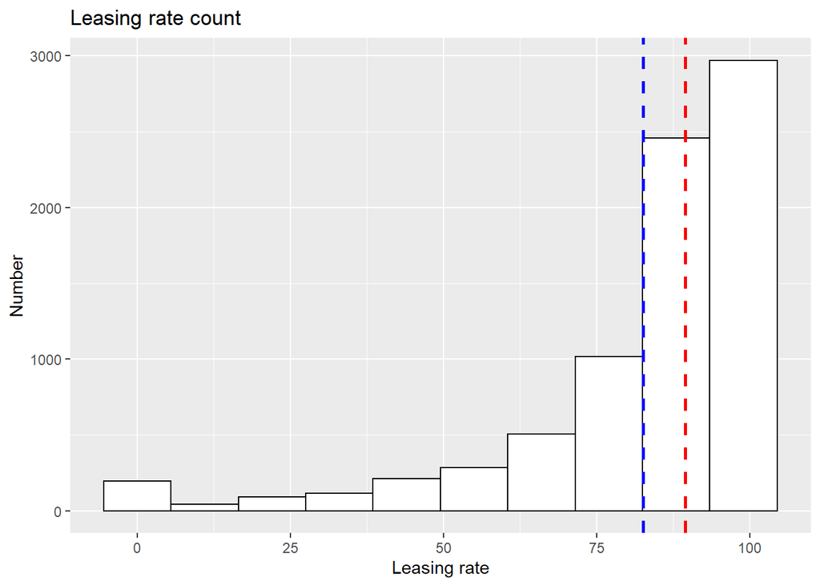

We found the median leasing rate to be ~90%, and the buildings with the lowest occupancy were highly skewed toward 0%, showing there is likely a variable not included in this data set that is impacting the buildings with the lowest occupancy rates. Further, considering 0% occupancy is quite far from the 90% median, it can be concluded that dropping the bottom 10% of buildings based on occupancy will likely not impact the model, and could even help increase its accuracy.

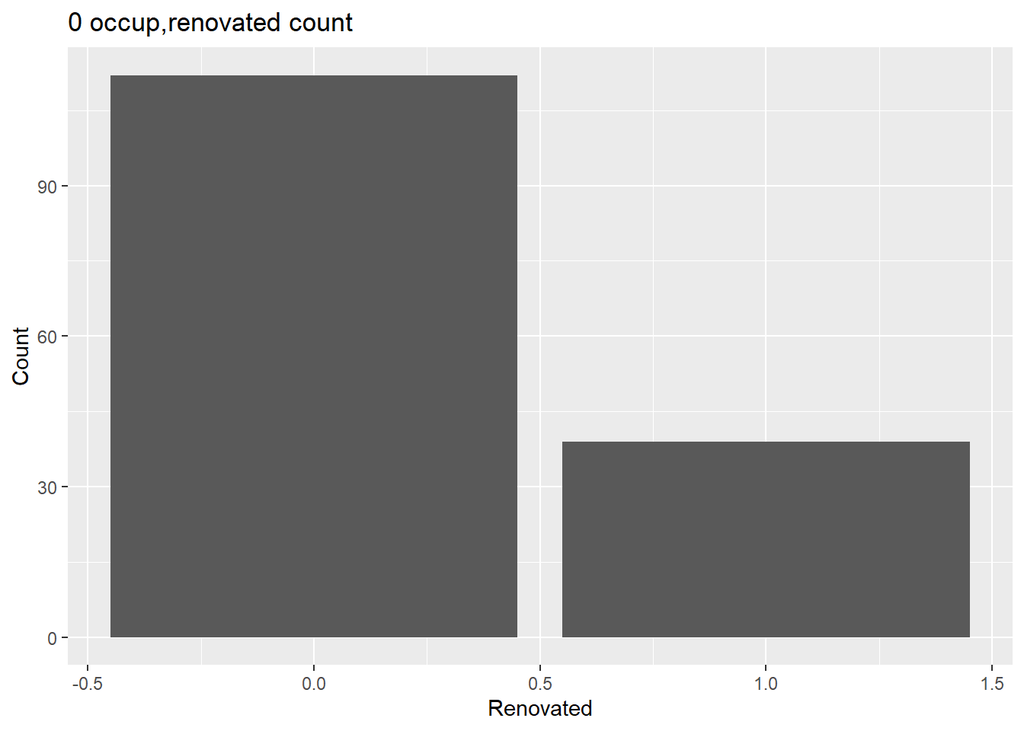

```
##  CS_PropertyID        cluster            size           empl_gr
##  Min.   :  10098   Min.   :   8.0   Min.   :  1624   Min.   :-1.490
##  1st Qu.: 240228   1st Qu.: 256.0   1st Qu.:  9784   1st Qu.: 1.755
##  Median : 410242   Median : 383.0   Median : 21340   Median : 2.380
##  Mean   :1335707   Mean   : 549.9   Mean   : 49114   Mean   : 4.120
##  3rd Qu.: 999549   3rd Qu.:1010.5   3rd Qu.: 71000   3rd Qu.: 3.700
##  Max.   :6008486   Max.   :1230.0   Max.   :427383   Max.   :67.780
##       Rent         leasing_rate    stories            age
##  Min.   :  7.00   Min.   :0     Min.   : 1.000   Min.   :  0.00
##  1st Qu.: 13.75   1st Qu.:0     1st Qu.: 2.000   1st Qu.: 28.00
##  Median : 19.40   Median :0     Median : 3.000   Median : 57.00
##  Mean   : 21.73   Mean   :0     Mean   : 4.212   Mean   : 55.04
##  3rd Qu.: 27.30   3rd Qu.:0     3rd Qu.: 5.000   3rd Qu.: 80.00
##  Max.   :111.11   Max.   :0     Max.   :19.000   Max.   :118.00
##    renovated         class_a          class_b            LEED
##  Min.   :0.0000   Min.   :0.0000   Min.   :0.0000   Min.   :0
##  1st Qu.:0.0000   1st Qu.:0.0000   1st Qu.:0.0000   1st Qu.:0
##  Median :0.0000   Median :0.0000   Median :0.0000   Median :0
##  Mean   :0.2583   Mean   :0.0596   Mean   :0.4503   Mean   :0
##  3rd Qu.:1.0000   3rd Qu.:0.0000   3rd Qu.:1.0000   3rd Qu.:0
##  Max.   :1.0000   Max.   :1.0000   Max.   :1.0000   Max.   :0
##    Energystar        green_rating           net             amenities
##  Min.   :0.000000   Min.   :0.000000   Min.   :0.000000   Min.   :0.00000
##  1st Qu.:0.000000   1st Qu.:0.000000   1st Qu.:0.000000   1st Qu.:0.00000
##  Median :0.000000   Median :0.000000   Median :0.000000   Median :0.00000
##  Mean   :0.006622   Mean   :0.006622   Mean   :0.006622   Mean   :0.08609
##  3rd Qu.:0.000000   3rd Qu.:0.000000   3rd Qu.:0.000000   3rd Qu.:0.00000
##  Max.   :1.000000   Max.   :1.000000   Max.   :1.000000   Max.   :1.00000
##   cd_total_07     hd_total07    total_dd_07   Precipitation
##  Min.   : 130   Min.   :   0   Min.   :2103   Min.   :10.46
##  1st Qu.: 684   1st Qu.:1419   1st Qu.:2869   1st Qu.:22.71
##  Median :1113   Median :2080   Median :4651   Median :25.55
##  Mean   :1683   Mean   :3013   Mean   :4696   Mean   :30.54
##  3rd Qu.:2746   3rd Qu.:4694   3rd Qu.:6363   3rd Qu.:41.32
##  Max.   :5240   Max.   :7200   Max.   :8244   Max.   :53.93
##    Gas_Costs        Electricity_Costs  cluster_rent
##  Min.   :0.009487   Min.   :0.01782   Min.   :10.22
##  1st Qu.:0.010118   1st Qu.:0.02463   1st Qu.:18.00
##  Median :0.010296   Median :0.02887   Median :20.25
##  Mean   :0.011799   Mean   :0.03182   Mean   :24.17
##  3rd Qu.:0.011955   3rd Qu.:0.03781   3rd Qu.:28.03
##  Max.   :0.028914   Max.   :0.06278   Max.   :65.94
```

There appear to be a notable number of buildings with 0% occupancy. On further analysis, it is apparent that the median age for low occupancy buildings is 57 as opposed to 34 for the main data set, as well as a lower number of renovated buildings among the buildings with lower occupancy. This could provide insight into the variables impacting the lowest 10% of buildings based on occupancy rate, such as ongoing renovation projects or lack of permit for occupancy due to hazardous conditions in these older buildings. This is a better explanation to account for the dropping of the bottom 10% of buildings as opposed to simply stating “something weird” is happening with them.

## Part 2

To test for a premium in rent for green buildings, we cannot simply subtract the difference between the two median rents among green and non-green buildings as we are not accounting for different factors that also affect revenue. To test if there is a true difference in price per square-foot, ideally, we would run a regression and hold other variables constant to see the individual effect on rent for a green building versus a non-green building.

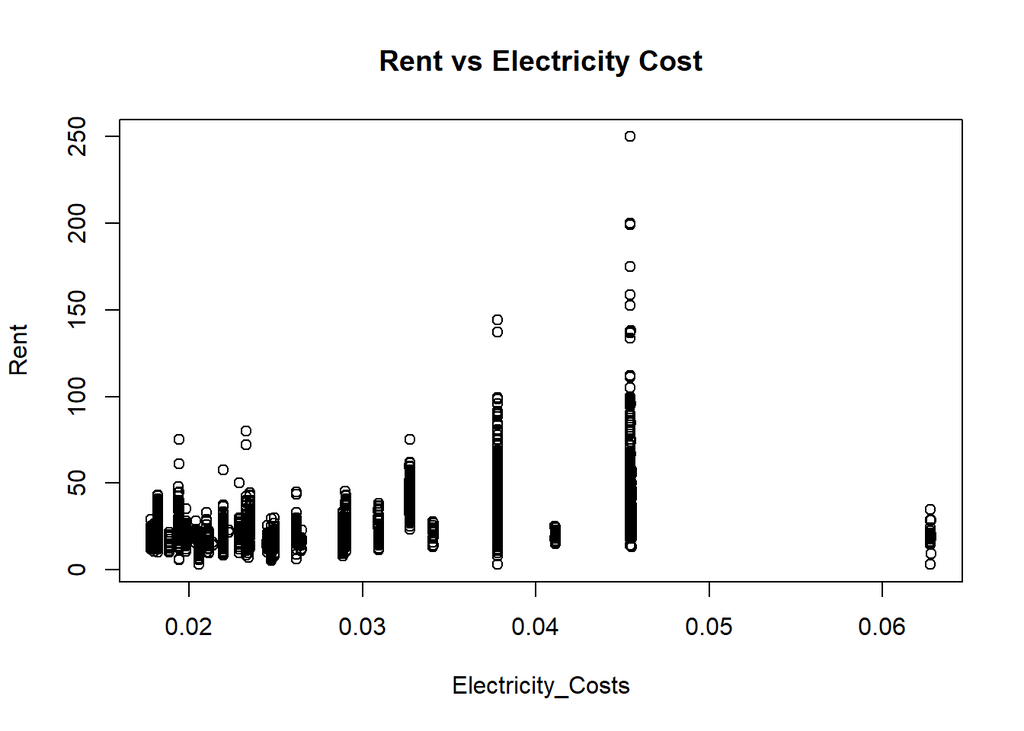

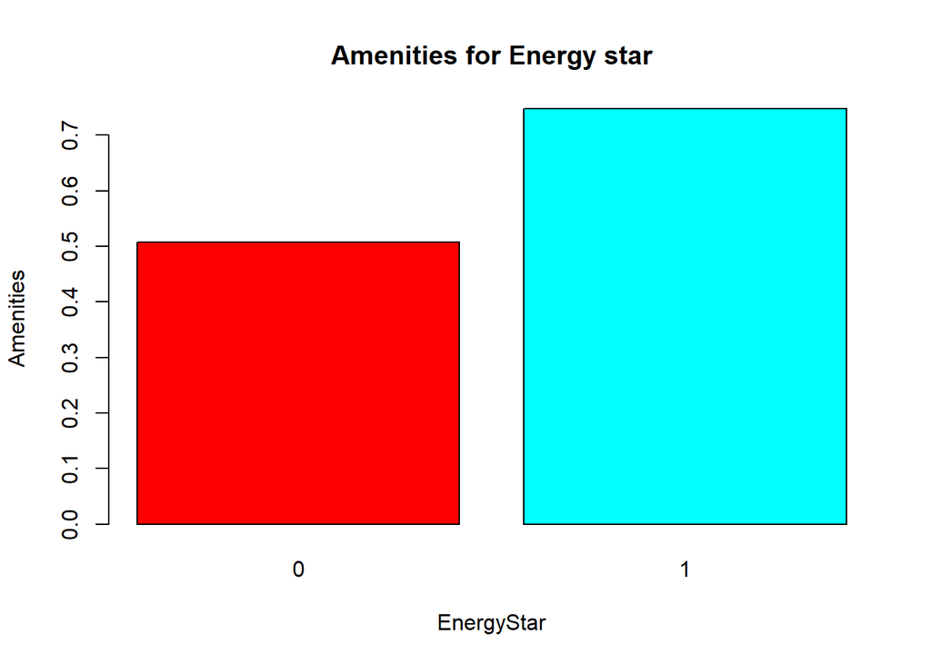

## Part 3

As seen above, as rent increases, electricity costs also increase, therefore one cannot simply assume a direct increase in profit with the increase in rent for green buildings. Furthermore, energy efficient buildings are more likely to have amenities. Both of these variables will increase overhead costs, further justifying a lack of certainty in a profit stemming from increased rent revenue generation in green buildings.

## Part 4

The calculation for $5 million in extra construction costs for a green building is valid, and as we previously stated, the Median occupancy rate is 90%, therefore it is safe to take a 90% test occupancy rate for recuperation calculations. This however does not mean the recuperation calculations are accurate due to variables not accounted for such as increased amenity and electricity costs, as explained above.

## Part 5

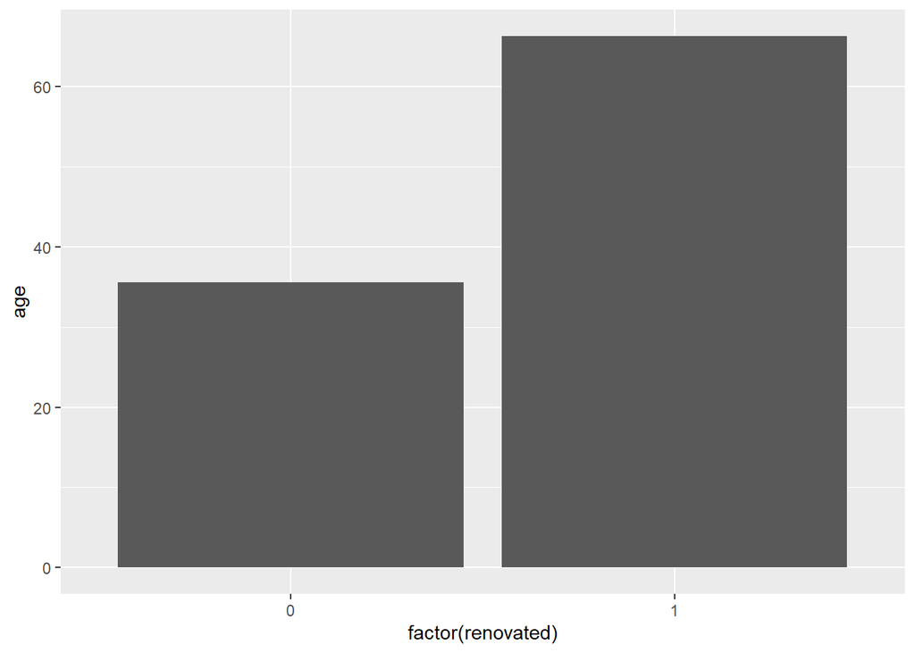

The stats guru assumes that the building will be earning rent for 30 years. This assumption is accurate since the average age for non-renovated buildings is 35. Therefore, the building will likely generate rent revenue for at least 30 years before undergoing a renovation. However, we cannot confirm that this is a financially good decision based purely on the stats guru’s conclusions, due to the presence of multiple confounding variables that are unaccounted for, as depicted in part 4.

## Part 6

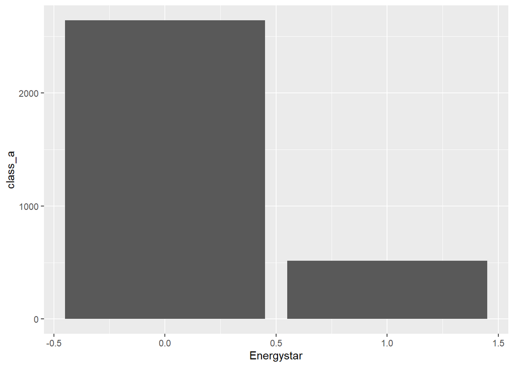

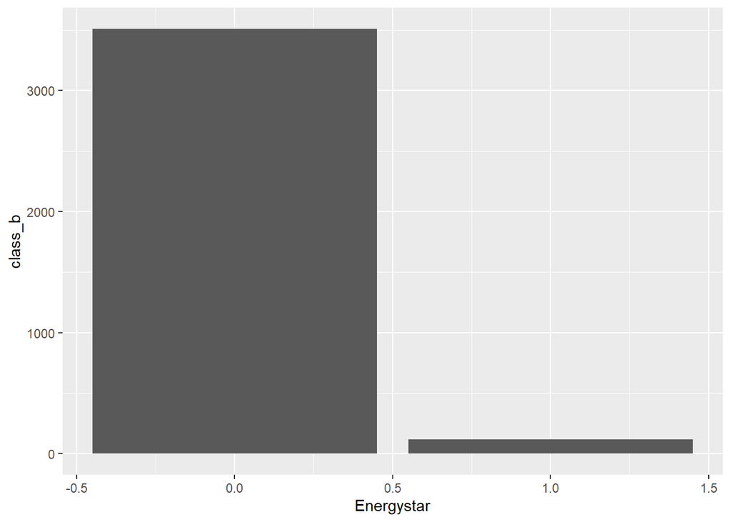

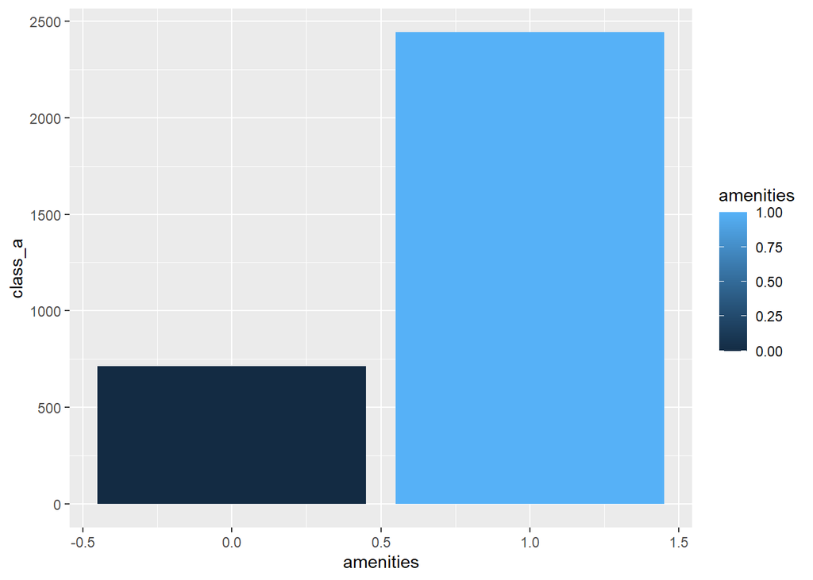

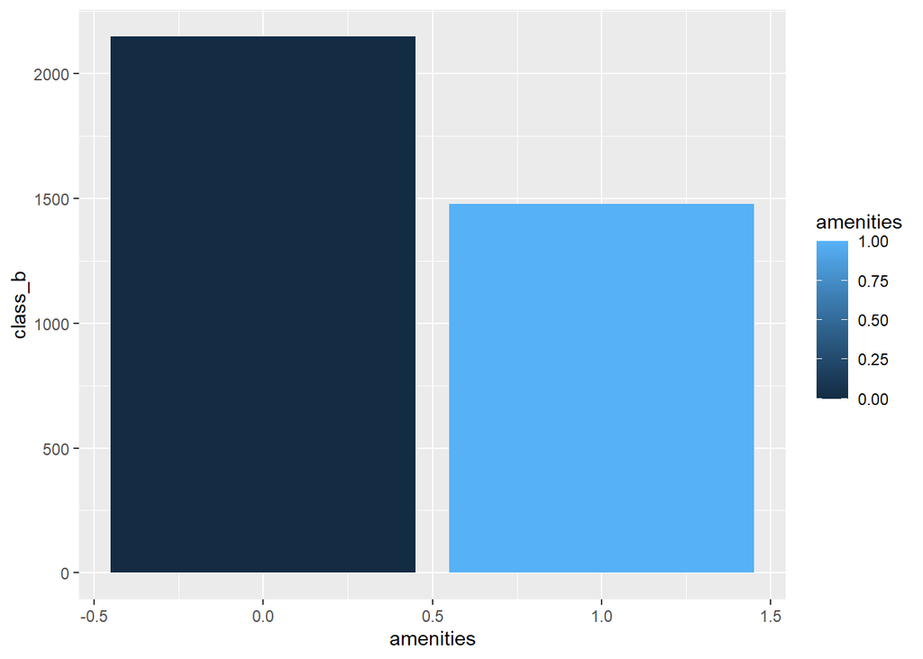

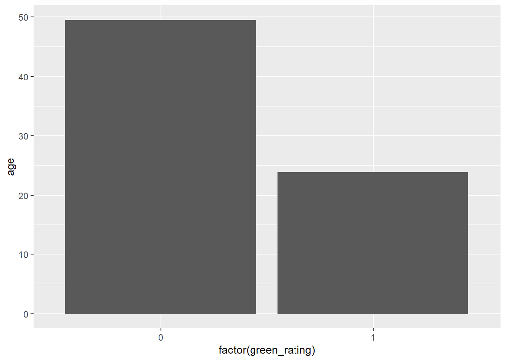

As seen above, the rent in a green status building can also be impacted by other variables beyond its green status. For example, building class type is correlated with green status. Green status buildings are more likely to be Class A buildings, and Class A buildings tend to experience an increase in amenities. So, it could be said that beyond green status, the rent of a green building is impacted by other variables such as amenities and class type. Some other confounding variables are Age and Employment Growth.

## Conclusion

For the majority of conclusions found by the stats guru, we are also unconvinced his findings are correct. The most common issue his work has is in not accounting for all variables that affect Rent. As described, we found several confounding variables in our data set that impact Rent of Green Buildings, so we know that the variables play off one another. Therefore, to create a model that accurately reflects the factors that impact the profit and financial attractiveness of this green building, all variables should be taken into account in a far deeper level than that which the stats guru attempted to do.

# Question 2 - Flights at ABIA

The intended audience for our analysis is airport schedulers / passengers of air travel. The plots display delays by various time periods.

## Part 1

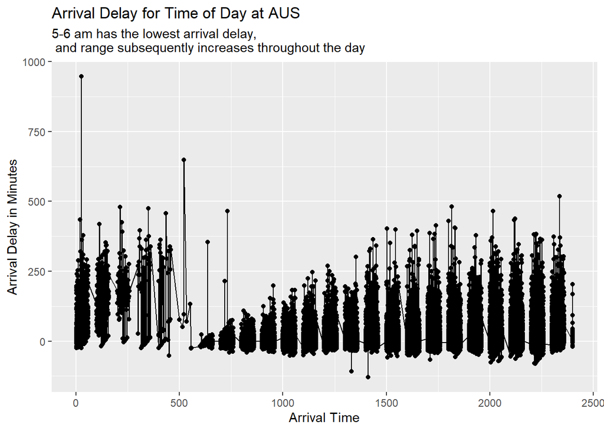

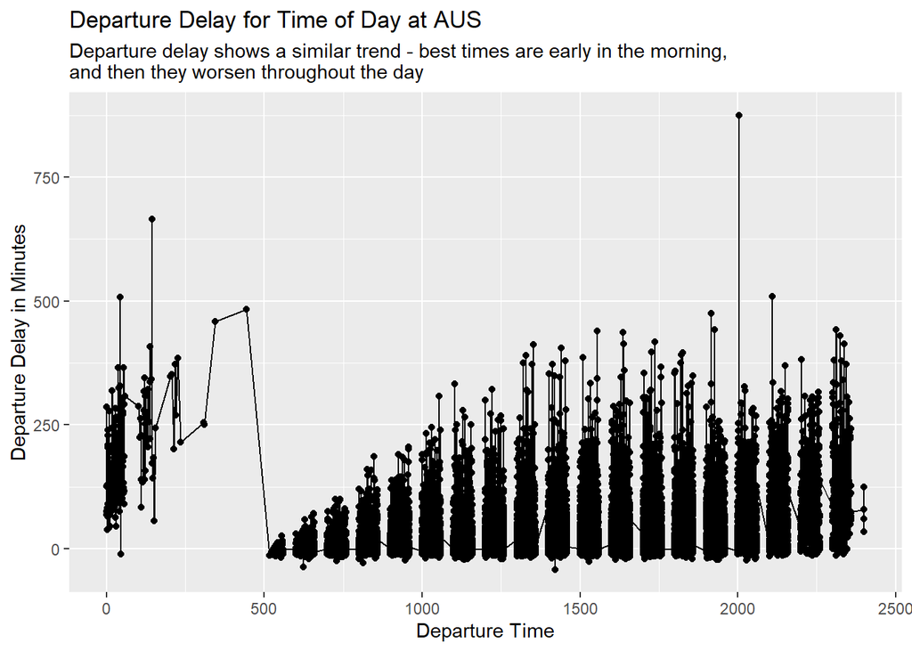

## Part 2

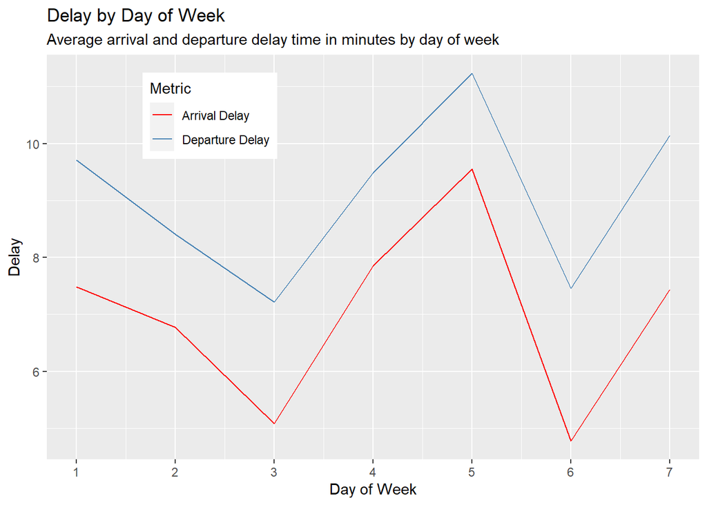

## Part 3

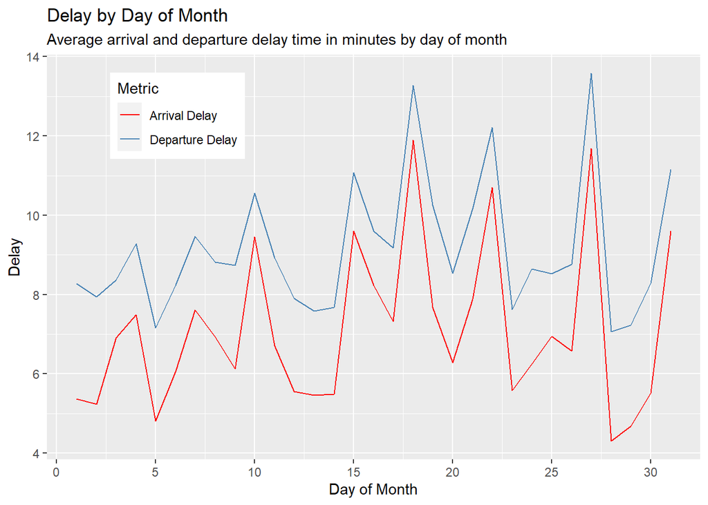

## Part 4

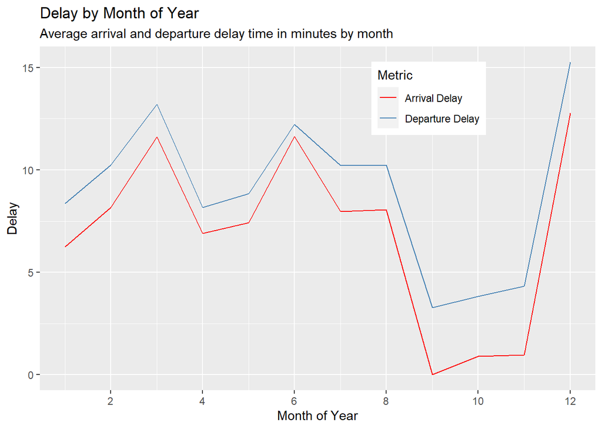

## Part 5

This plot shows flights on time for the best 4 airlines, as determined by [The Points Guy](https://thepointsguy.com/news/tpg-2021-best-us-airlines/).

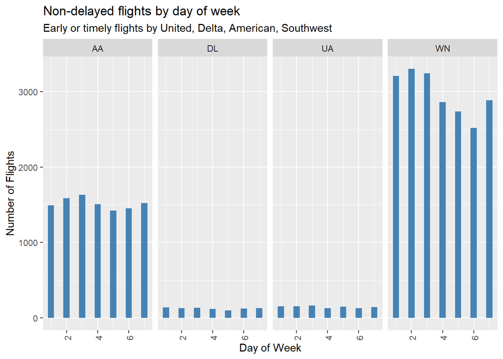

# Question 3 - Portfolio Modelling

Here is a short description of the ETFs we chose for this model:

- Equity- Large Cap Growth - SPY
- Equity- Small Cap Growth - IWM
- Large Cap- Blend - RSP
- Bonds- UST 1-3 YR - SHY
- Hedge Fund - DBEF

## Part 1

Adjusting all stocks

## Part 2

Combine all the returns in a matrix

```
##               ClCl.SPYa    ClCl.IWMa    ClCl.RSPa     ClCl.SHYa   ClCl.DBEFa
## 2015-12-01           NA           NA           NA            NA           NA
## 2015-12-02 -0.010205022 -0.010759872 -0.013179302 -0.0008276188 -0.006657358
## 2015-12-03 -0.014002772 -0.016863407 -0.014245777  0.0000000000 -0.025044127
## 2015-12-04  0.019502913  0.010120077  0.015871006  0.0002366229  0.015195370
## 2015-12-07 -0.006058530 -0.015027993 -0.008002095 -0.0001183249 -0.003207413
## 2015-12-08 -0.006719505 -0.005516757 -0.007042190 -0.0001182560 -0.018591277
```

## Part 3

Calculating returns for each ETF

```
##                SPY     IWM     RSP     SHY    DBEF
## 2015-12-01  0.5921  0.2341  0.6443  0.0828 -0.0350
## 2015-12-02 -1.0205 -1.0760 -1.3179 -0.0828 -0.6657
## 2015-12-03 -1.4003 -1.6863 -1.4246  0.0000 -2.5044
## 2015-12-04  1.9503  1.0120  1.5871  0.0237  1.5195
## 2015-12-07 -0.6059 -1.5028 -0.8002 -0.0118 -0.3207
## 2015-12-08 -0.6720 -0.5517 -0.7042 -0.0118 -1.8591
## 2015-12-09 -0.7780 -1.1181 -0.6963  0.0355 -1.2750
## 2015-12-10  0.2581  0.3331  0.1428 -0.0591  0.1845
## 2015-12-11 -1.9381 -2.2278 -1.9450  0.1184 -1.9889
## 2015-12-14  0.5052 -0.7149  0.1455 -0.1182  0.2631
```

```
##             SPY        IWM        RSP        SHY       DBEF
## SPY   1.0000000  0.8779136  0.9569717 -0.3188806  0.8802487
## IWM   0.8779136  1.0000000  0.9254979 -0.2865132  0.8175091
## RSP   0.9569717  0.9254979  1.0000000 -0.3151058  0.8760220
## SHY  -0.3188806 -0.2865132 -0.3151058  1.0000000 -0.3790187
## DBEF  0.8802487  0.8175091  0.8760220 -0.3790187  1.0000000
```

Now, let’s figure out how to set their weights accordingly. For this, we calculate the daily returns for each ETF and find their the median and standard deviation to understand their mean returns and volatility.

## Part 4

Getting the median return and volatility for each ETF

```
##             SPY      IWM      RSP     SHY     DBEF
## mean     0.0669   0.0588   0.0614  0.0060   0.0394
## sd       1.1522   1.4543   1.2477  0.0621   1.1162
## median   0.0767   0.1066   0.0830  0.0000   0.1125
## min    -10.9424 -13.2669 -12.0415 -0.4384 -10.6925
## max      9.0603   9.1491  10.6754  0.5452   7.1341
```

## Part 5 - Modelling the Portfolios

### Portfolio 1 - Aggressive portfolio

Profit/loss

```
## [1] 101092.5
```

```
## [1] 1092.469
```

5% value at risk:

```
##       5%
## 7965.996
```

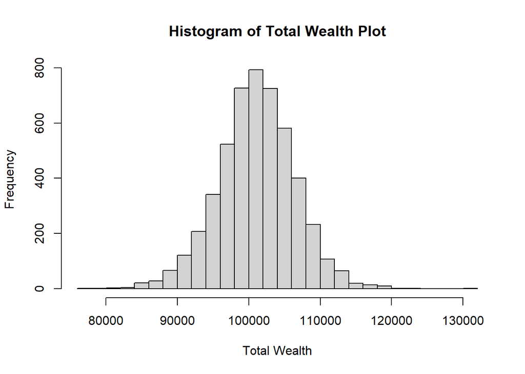

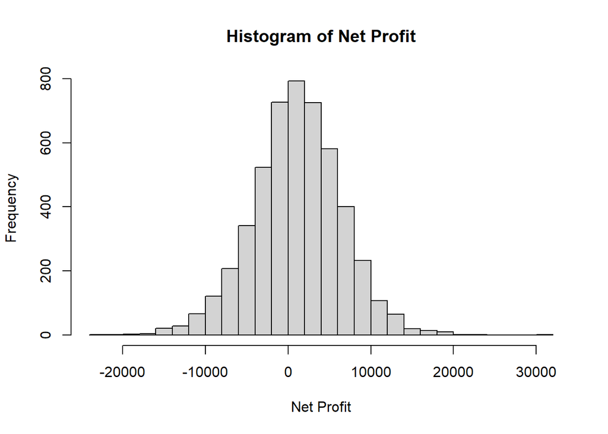

### Portfolio 2 - Balanced

Profit/loss

```
## [1] 101038.1
```

```
## [1] 1038.082
```

5% value at risk

```
##       5%
## 5957.573
```

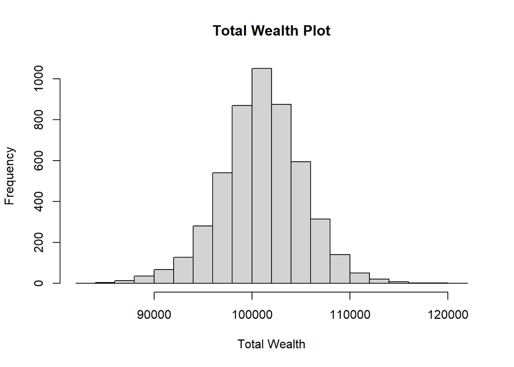

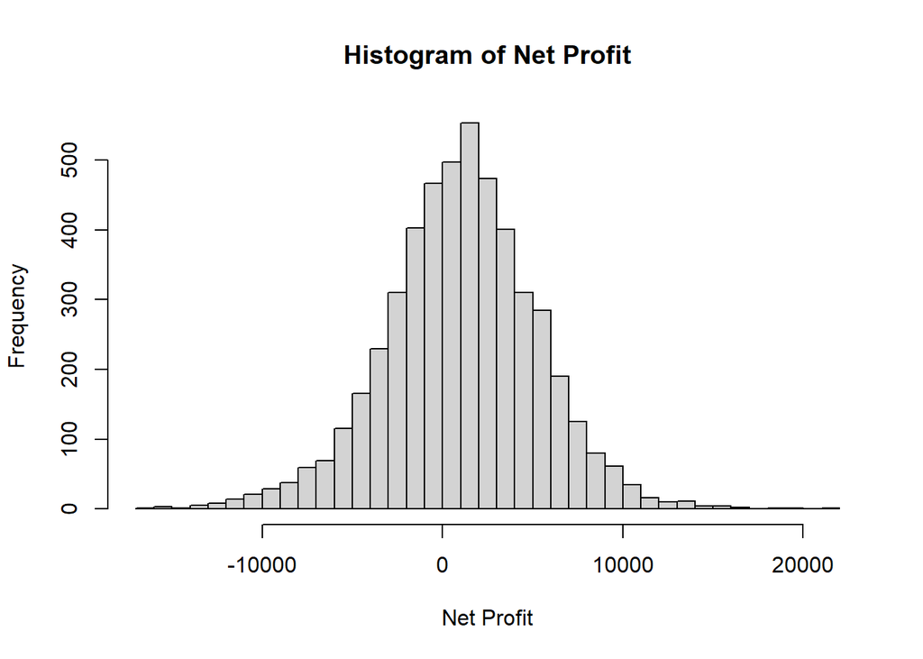